# Task 1 | House Price Prediction

Subhajit Karmakar

2023-07-18

## Introduction

This dataset contains house sale prices for King County, which includes Seattle. It includes homes sold between May 2014 and May 2015. Many features are there in the data, using those, we will build a regression model that will help us to predict the price of a new house.

**Data scource:** https://www.kaggle.com/datasets/harlfoxem/housesalesprediction?datasetId=128&sortBy=voteCount&language=R

```r
library(tidyverse)
library(ggcorrplot)
library(gridExtra)
library(caTools)
library(glue)
library(olsrr)

df <- read_csv("D:/Internships/Technohack/Task - 1/data.csv")

# first few rows of the data:
knitr::kable(head(df[1:5,]), format = 'html') %>%
  kableExtra::kable_styling()
```

| id | date | price | bedrooms | bathrooms | sqft_living | sqft_lot | floors | waterfront | view | condition | grade | sqft_above | sqft_basement | yr_built | yr_renovated | zipcode | lat | long | sqft_living15 | sqft_lot15 |
| --- | --- | --- | --- | --- | --- | --- | --- | --- | --- | --- | --- | --- | --- | --- | --- | --- | --- | --- | --- | --- |
| 7129300520 | 2014-10-13 | 221900 | 3 | 1.00 | 1180 | 5650 | 1 | 0 | 0 | 3 | 7 | 1180 | 0 | 1955 | 0 | 98178 | 47.5112 | -122.257 | 1340 | 5650 |
| 6414100192 | 2014-12-09 | 538000 | 3 | 2.25 | 2570 | 7242 | 2 | 0 | 0 | 3 | 7 | 2170 | 400 | 1951 | 1991 | 98125 | 47.7210 | -122.319 | 1690 | 7639 |
| 5631500400 | 2015-02-25 | 180000 | 2 | 1.00 | 770 | 10000 | 1 | 0 | 0 | 3 | 6 | 770 | 0 | 1933 | 0 | 98028 | 47.7379 | -122.233 | 2720 | 8062 |
| 2487200875 | 2014-12-09 | 604000 | 4 | 3.00 | 1960 | 5000 | 1 | 0 | 0 | 5 | 7 | 1050 | 910 | 1965 | 0 | 98136 | 47.5208 | -122.393 | 1360 | 5000 |
| 1954400510 | 2015-02-18 | 510000 | 3 | 2.00 | 1680 | 8080 | 1 | 0 | 0 | 3 | 8 | 1680 | 0 | 1987 | 0 | 98074 | 47.6168 | -122.045 | 1800 | 7503 |

```r
glimpse(df)
```

```
## Rows: 21,613
## Columns: 21
## $ id            <chr> "7129300520", "6414100192", "5631500400", "2487200875", …
## $ date          <dttm> 2014-10-13, 2014-12-09, 2015-02-25, 2014-12-09, 2015-02…
## $ price         <dbl> 221900, 538000, 180000, 604000, 510000, 1225000, 257500,…
## $ bedrooms      <dbl> 3, 3, 2, 4, 3, 4, 3, 3, 3, 3, 3, 2, 3, 3, 5, 4, 3, 4, 2,…
## $ bathrooms     <dbl> 1.00, 2.25, 1.00, 3.00, 2.00, 4.50, 2.25, 1.50, 1.00, 2.…
## $ sqft_living   <dbl> 1180, 2570, 770, 1960, 1680, 5420, 1715, 1060, 1780, 189…
## $ sqft_lot      <dbl> 5650, 7242, 10000, 5000, 8080, 101930, 6819, 9711, 7470,…
## $ floors        <dbl> 1.0, 2.0, 1.0, 1.0, 1.0, 1.0, 2.0, 1.0, 1.0, 2.0, 1.0, 1…
## $ waterfront    <dbl> 0, 0, 0, 0, 0, 0, 0, 0, 0, 0, 0, 0, 0, 0, 0, 0, 0, 0, 0,…
## $ view          <dbl> 0, 0, 0, 0, 0, 0, 0, 0, 0, 0, 0, 0, 0, 0, 0, 3, 0, 0, 0,…
## $ condition     <dbl> 3, 3, 3, 5, 3, 3, 3, 3, 3, 3, 3, 4, 4, 4, 3, 3, 3, 4, 4,…
## $ grade         <dbl> 7, 7, 6, 7, 8, 11, 7, 7, 7, 7, 8, 7, 7, 7, 7, 9, 7, 7, 7…
## $ sqft_above    <dbl> 1180, 2170, 770, 1050, 1680, 3890, 1715, 1060, 1050, 189…
## $ sqft_basement <dbl> 0, 400, 0, 910, 0, 1530, 0, 0, 730, 0, 1700, 300, 0, 0, …
## $ yr_built      <dbl> 1955, 1951, 1933, 1965, 1987, 2001, 1995, 1963, 1960, 20…
## $ yr_renovated  <dbl> 0, 1991, 0, 0, 0, 0, 0, 0, 0, 0, 0, 0, 0, 0, 0, 0, 0, 0,…
## $ zipcode       <dbl> 98178, 98125, 98028, 98136, 98074, 98053, 98003, 98198, …
## $ lat           <dbl> 47.5112, 47.7210, 47.7379, 47.5208, 47.6168, 47.6561, 47…
## $ long          <dbl> -122.257, -122.319, -122.233, -122.393, -122.045, -122.0…
## $ sqft_living15 <dbl> 1340, 1690, 2720, 1360, 1800, 4760, 2238, 1650, 1780, 23…
## $ sqft_lot15    <dbl> 5650, 7639, 8062, 5000, 7503, 101930, 6819, 9711, 8113, …
```

```r
glue("Number of NA value present in the data: {n}",
     n = df %>% is.na() %>% sum())
```

```
## Number of NA value present in the data: 0
```

**Observation:** We can see that there are many categorical variables in the data, but they are not in proper format. First we will get an idea about the frequency distribution of the `categorical` variables.

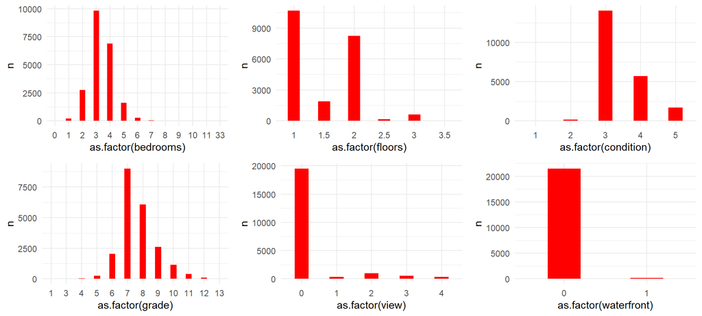

```r
# function to make the frequency distribution:
count_plot <- function(var){
  df %>% count({{var}}) %>%
    ggplot(aes(x = as.factor({{var}}), y = n)) +
    geom_bar(stat = 'identity', position = position_dodge2(),
             fill = 'red', width = 0.4) +
    theme(axis.title = element_text(face = 'bold', size = 25),
          axis.text = element_text(face = 'bold', size = 15)) +
    theme_minimal()
}

attach(df)
count_plot(bedrooms) -> c1
count_plot(floors) -> c2
count_plot(condition) -> c3
count_plot(grade) -> c4
count_plot(view) -> c5
count_plot(waterfront) -> c6
grid.arrange(c1,c2,c3,c4,c5,c6, nrow = 2)
```

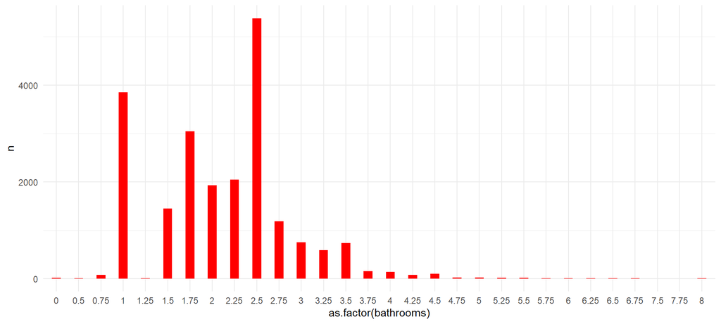

```r
count_plot(bathrooms)
```

```r
detach(df)
```

**Observation:** We can see that some categorical variables have too many levels, which might create problems in data visualization. In the next few lines of code, we will modify the levels and proceed with data visualization. But let us first see the distribution of the price of the houses.

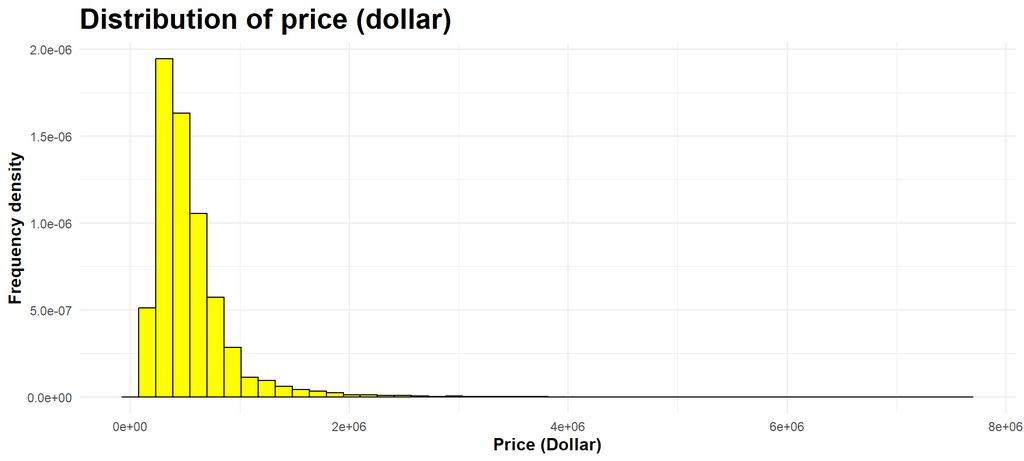

```r
ggplot(df, aes(price)) + geom_histogram(aes(y = after_stat(density)),
                                        fill = 'yellow',
                                        colour = 'black',
                                        bins = 50) +
  labs(title = 'Distribution of price (dollar)',
       x = 'Price (Dollar)', y = 'Frequency density') +
  theme_minimal() +
  theme(plot.title = element_text(face = 'bold', size = 20),
        axis.title = element_text(face = 'bold', size = 12))
```

We note that the distribution is highly skewed, so while making the visualizations, we will consider the `log` of the price for better understanding.

```r
df1 <- df # saving a copy of the original data
summary(df1)
```

```
##       id                 date                            price
##  Length:21613       Min.   :2014-05-02 00:00:00.00   Min.   :  75000
##  Class :character   1st Qu.:2014-07-22 00:00:00.00   1st Qu.: 321950
##  Mode  :character   Median :2014-10-16 00:00:00.00   Median : 450000
##                     Mean   :2014-10-29 04:38:01.96   Mean   : 540088
##                     3rd Qu.:2015-02-17 00:00:00.00   3rd Qu.: 645000
##                     Max.   :2015-05-27 00:00:00.00   Max.   :7700000
##     bedrooms        bathrooms      sqft_living       sqft_lot
##  Min.   : 0.000   Min.   :0.000   Min.   :  290   Min.   :    520
##  1st Qu.: 3.000   1st Qu.:1.750   1st Qu.: 1427   1st Qu.:   5040
##  Median : 3.000   Median :2.250   Median : 1910   Median :   7618
##  Mean   : 3.371   Mean   :2.115   Mean   : 2080   Mean   :  15107
##  3rd Qu.: 4.000   3rd Qu.:2.500   3rd Qu.: 2550   3rd Qu.:  10688
##  Max.   :33.000   Max.   :8.000   Max.   :13540   Max.   :1651359
##      floors        waterfront            view          condition
##  Min.   :1.000   Min.   :0.000000   Min.   :0.0000   Min.   :1.000
##  1st Qu.:1.000   1st Qu.:0.000000   1st Qu.:0.0000   1st Qu.:3.000
##  Median :1.500   Median :0.000000   Median :0.0000   Median :3.000
##  Mean   :1.494   Mean   :0.007542   Mean   :0.2343   Mean   :3.409
##  3rd Qu.:2.000   3rd Qu.:0.000000   3rd Qu.:0.0000   3rd Qu.:4.000
##  Max.   :3.500   Max.   :1.000000   Max.   :4.0000   Max.   :5.000
##      grade          sqft_above   sqft_basement       yr_built
##  Min.   : 1.000   Min.   : 290   Min.   :   0.0   Min.   :1900
##  1st Qu.: 7.000   1st Qu.:1190   1st Qu.:   0.0   1st Qu.:1951
##  Median : 7.000   Median :1560   Median :   0.0   Median :1975
##  Mean   : 7.657   Mean   :1788   Mean   : 291.5   Mean   :1971
##  3rd Qu.: 8.000   3rd Qu.:2210   3rd Qu.: 560.0   3rd Qu.:1997
##  Max.   :13.000   Max.   :9410   Max.   :4820.0   Max.   :2015
##   yr_renovated       zipcode           lat             long
##  Min.   :   0.0   Min.   :98001   Min.   :47.16   Min.   :-122.5
##  1st Qu.:   0.0   1st Qu.:98033   1st Qu.:47.47   1st Qu.:-122.3
##  Median :   0.0   Median :98065   Median :47.57   Median :-122.2
##  Mean   :  84.4   Mean   :98078   Mean   :47.56   Mean   :-122.2
##  3rd Qu.:   0.0   3rd Qu.:98118   3rd Qu.:47.68   3rd Qu.:-122.1
##  Max.   :2015.0   Max.   :98199   Max.   :47.78   Max.   :-121.3
##  sqft_living15    sqft_lot15
##  Min.   : 399   Min.   :   651
##  1st Qu.:1490   1st Qu.:  5100
##  Median :1840   Median :  7620
##  Mean   :1987   Mean   : 12768
##  3rd Qu.:2360   3rd Qu.: 10083
##  Max.   :6210   Max.   :871200
```

```r
# re-leveling the categorical columns and modification of the columns

df1 %>% mutate(bedrooms = case_when(
  bedrooms <= 3 ~ "<=3",
  bedrooms > 3 ~ ">3"
)) %>% mutate(bedrooms = as.factor(bedrooms)) -> df1
df$bedrooms <- as.factor(df$bedrooms)


df1 %>% mutate(bathrooms = case_when(
  bathrooms <= 1.5 ~ "<=1.5",
  bathrooms > 1.5 & bathrooms <= 2.5 ~ "(1.5,2.5]",
  bathrooms > 2.5 ~ ">2.5"
)) %>% mutate(bathrooms = as.factor(bathrooms)) -> df1
df$bathrooms <- as.factor(df$bathrooms)


df1 %>% mutate(floors = case_when(
  floors < 2 ~ "<2",
  floors >= 2 ~ ">=2"
)) %>% mutate(floors = as.factor(floors)) -> df1
df$floors <- as.factor(df$floors)


df1 %>% mutate(condition = case_when(
  condition <= 3 ~ '0',
  condition > 3 ~ '1'
)) %>% mutate(condition = as.factor(condition)) -> df1
df$condition <- as.factor(df$condition)


df1 %>% mutate(grade = case_when(
  grade <= 6 ~ '0',
  grade > 6 & grade <= 8 ~ '1',
  grade > 8 ~ '2'
)) %>% mutate(grade = as.factor(grade)) -> df1
df$grade <- as.factor(df$grade)


df1 %>% mutate(view = case_when(
  view == 0 ~ '0',
  view > 0 ~ '1'
)) %>% mutate(view = as.factor(view)) -> df1
df$view <- as.factor(df$view)


df1 %>% mutate(renovated = case_when(
  yr_renovated == 0 ~ '0',
  yr_renovated > 0 ~ '1'
)) %>% mutate(renovated = as.factor(renovated)) -> df1

df$waterfront <- as.factor(df$waterfront)
df1$waterfront <- as.factor(df1$waterfront)


# For model
df2 <- df %>% select(-c(id,date,sqft_basement))
```

**Note:** For data visualization, we will use the `df1` dataframe and for model building in future, we will use the `df2` dataframe. Also, from the `summary` of the data, we can see that a lot of `0` in the `sqft_basement` column, so we will delete that to avoid confusion.

## Data visualization

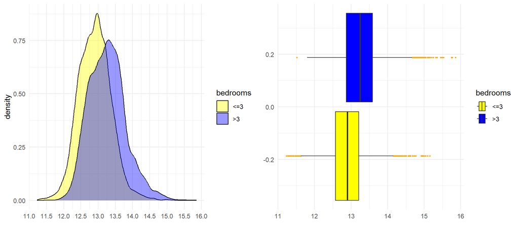

```r
# price ~ categorical variables:
plot2 <- function(fill_var){
  cols <- c('yellow','blue','red')

  df1 %>% ggplot(aes(log(price), fill = {{fill_var}})) +
    geom_density(colour = 'black', alpha = 0.4) +
    scale_x_continuous(n.breaks = 10) +
    labs(x = '') + theme_minimal() +
    scale_fill_manual(values = cols) -> p1

  df1 %>% ggplot(aes(log(price), fill = {{fill_var}})) +
    geom_boxplot(outlier.colour = 'orange',
                 outlier.size = 0.6) +
    labs(x = '') +theme_minimal() +
    scale_fill_manual(values = cols) -> p2
  grid.arrange(p1,p2, ncol = 2)
}

attach(df1)
plot2(bedrooms)
```

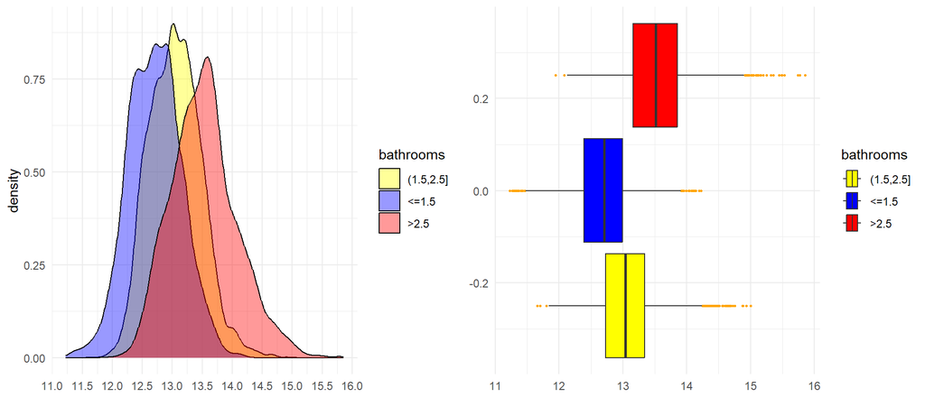

```r
plot2(bathrooms)
```

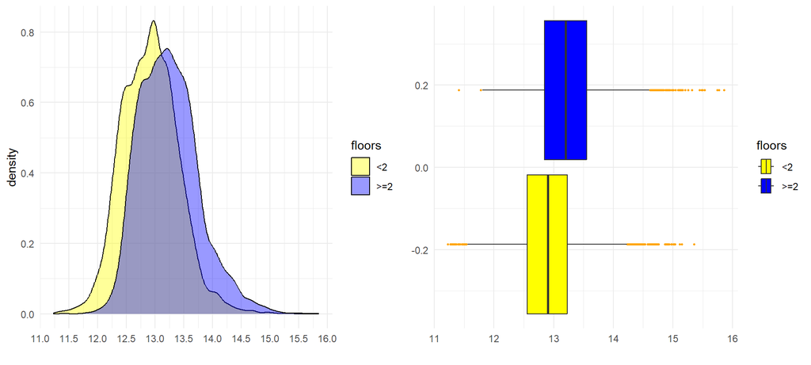

```r
plot2(floors)
```

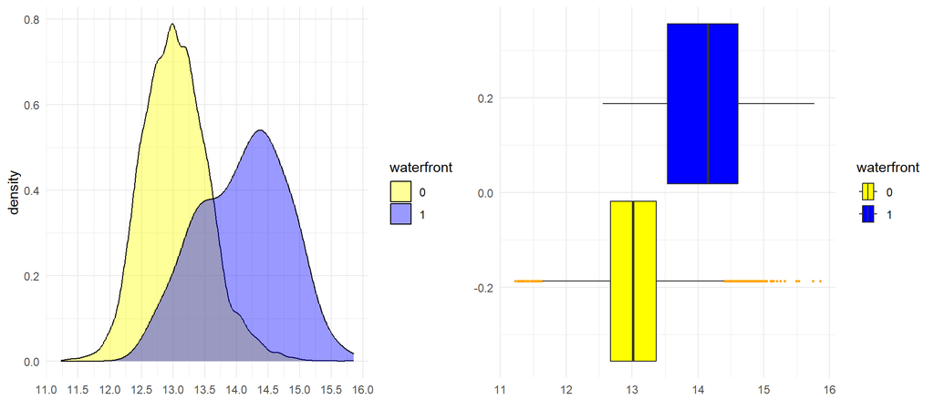

```r
plot2(waterfront)
```

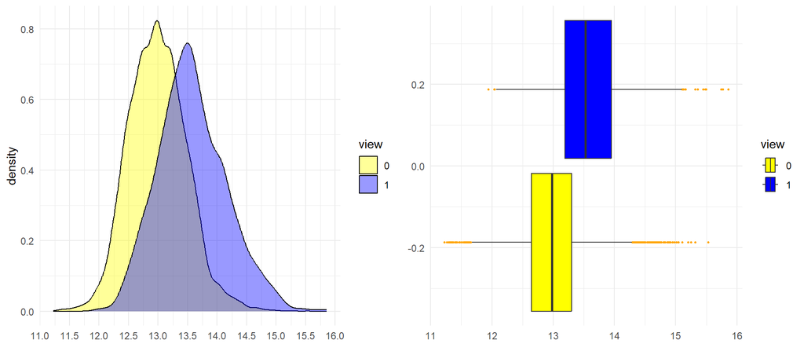

```r
plot2(view)
```

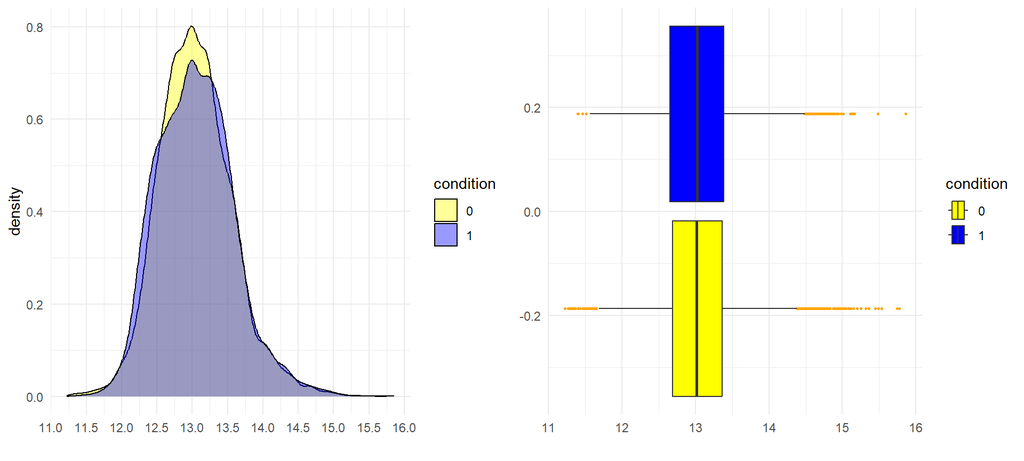

```r
plot2(condition)
```

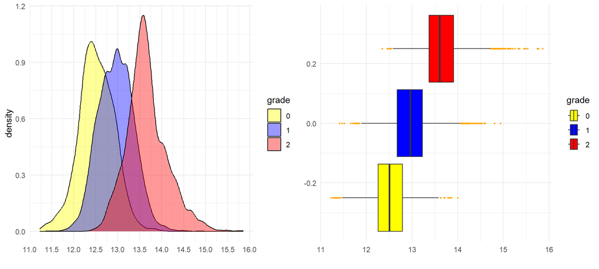

```r
plot2(grade)
```

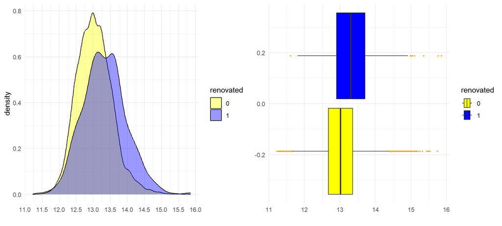

```r
plot2(renovated)
```

```r
detach(df1)
```

**Interpretation:** From the above plots, we can see that some categorical variables are very significant. For example, the price of the house increases with the number of bedrooms a house has, similar patterns are present in the cases of `bathrooms`,`floors`,`grade` etc. The presence of the waterfront is affecting the price very much, also the `view`. But we can see that the condition of a house does not affect the price too much, similarly, the price does not depend too much on whether a house is renovated or not at all.

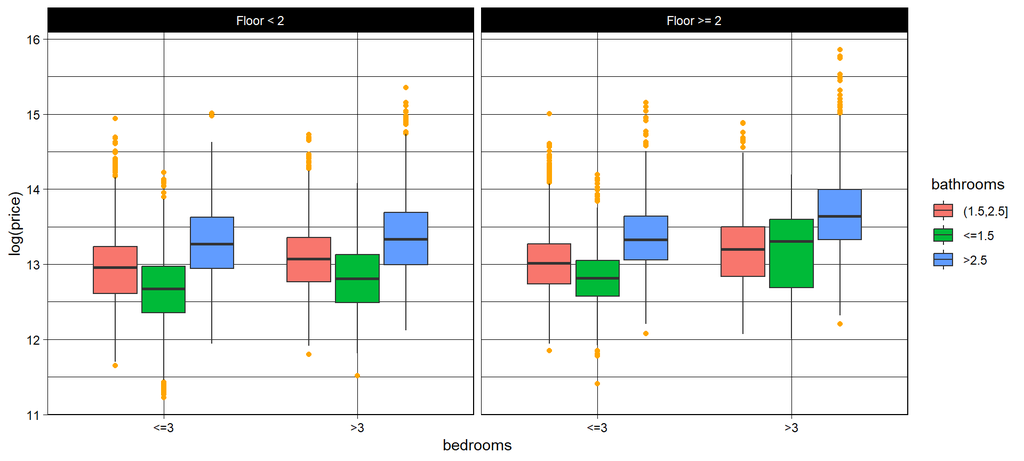

```r
name1 <- c('<2' = 'Floor < 2','>=2' = 'Floor >= 2')
df1 %>% ggplot(aes(x = bedrooms, y = log(price), fill = bathrooms)) +
  geom_boxplot(outlier.colour = 'orange') +
  facet_wrap(.~floors, labeller =
              labeller(floors = as_labeller(name1, label_context))) +
  theme_linedraw()
```

**Comment:** We have specifies earlier that we have considered the logarithm of `price` for better understanding of the visualizations, since the distribution of price variable is highly skewed. From this plot, we can get an idea about the distribution of the price with respect to 3 categorical variables. If the number of floors in the house is more than 2 and more than 2.5 bathrooms are there, then the price of the house tends to be very high which is very obvious, provided that the house contains more than 3 bedrooms. The overall idea we get from the plot is that, price is very much dependent on the number of floors and bathrooms, but the number of bedrooms does not affect too much since the location of the boxplots is not changing significantly w.r.t the levels of bedrooms.

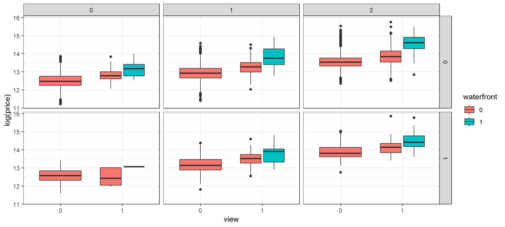

```r
df1 %>% ggplot(aes(x = view, y = log(price), fill = waterfront)) +
  geom_boxplot() + facet_grid(renovated ~ grade) +
  theme_bw()
```

**Comment:** It is evident from the plot that, the `grade` is a significant factor for determining the price, it increases with the grade which is obvious. But another observation is that, for the renovated houses, the variation in price has decreased. Also, no waterfront is there in case of `view = 0`.

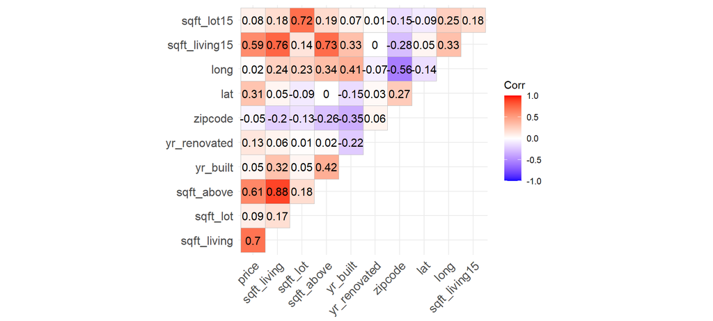

```r
df2 %>% select(where(is_double)) %>%
  cor() %>% ggcorrplot(lab = T, type = 'upper',
                       ggtheme = ggplot2::theme_minimal)
```

**Comment:** From the above plot, we can get an idea about the relationships between the variables. There are some weak correlations between `price` and some covariates. It is also clear that, multicollinearity is present in the numeric features, we will check for the multicollinearity statistically and omit the necessay numeric features.

```r
l1 <- lm(price ~ sqft_lot15 + sqft_living15 + long + lat +
          zipcode + yr_renovated + yr_built +
          sqft_above + sqft_lot + sqft_living, data = df2)

ols_vif_tol(l1)
```

```
##        Variables Tolerance      VIF
## 1     sqft_lot15 0.4713961 2.121358
## 2  sqft_living15 0.3851588 2.596332
## 3           long 0.5733860 1.744026
## 4            lat 0.8937764 1.118848
## 5        zipcode 0.6238392 1.602977
## 6   yr_renovated 0.9286359 1.076848
## 7       yr_built 0.6691257 1.494488
## 8     sqft_above 0.1949860 5.128574
## 9       sqft_lot 0.4772326 2.095414
## 10   sqft_living 0.1922506 5.201544
```

We can see that, VIF is more than 5 for `sqft_living` and `sqft_above`, so first we will omit the `sqft_living` variable since VIF is highest for this case only and we will check agin for the presence of multicollinearity.

```r
df2 <- df2 %>% select(-sqft_living)

l2 <- lm(price ~ sqft_lot15 + sqft_living15 + long + lat +
          zipcode + yr_renovated + yr_built +
          sqft_above + sqft_lot, data = df2)

ols_vif_tol(l2)
```

```
##       Variables Tolerance      VIF
## 1    sqft_lot15 0.4714302 2.121205
## 2 sqft_living15 0.4457814 2.243252
## 3          long 0.5858554 1.706906
## 4           lat 0.8966744 1.115232
## 5       zipcode 0.6238443 1.602964
## 6  yr_renovated 0.9315979 1.073424
## 7      yr_built 0.6713474 1.489542
## 8    sqft_above 0.4137434 2.416957
## 9      sqft_lot 0.4777874 2.092981
```

Now, all the VIF values are strictly less than 5, so we can safely say that there is no multicolliearity in the data.

## Model fitting

Now, we will fit a multiple linear regression to our data which can predict the price of a new house.

```r
# Splitting the dataset (considering 75:24 ratio)
set.seed(123)
s <- sample.split(df2$price, SplitRatio = 3/4)
train_data <- df2[s,]
test_data <- df2[!s,]

f <- function(d)(paste(d[1], 'x', d[2]))
glue::glue("Dimension of training data: {d1}",
           "Dimension of testing data: {d2}",
           d1 = f(dim(train_data)), d2 = f(dim(test_data)),
           .sep = '\n')
```

```
## Dimension of training data: 16956 x 17
## Dimension of testing data: 4657 x 17
```

```r
l <- lm(price ~ ., data = train_data)
summary(l)
```

```
##
## Call:
## lm(formula = price ~ ., data = train_data)
##
## Residuals:
##      Min       1Q   Median       3Q      Max
## -2230258   -93631    -9448    74705  4270738
##
## Coefficients:
##                 Estimate Std. Error t value Pr(>|t|)
## (Intercept)    5.700e+06  3.271e+06   1.743 0.081379 .
## bedrooms1     -1.927e+04  8.880e+04  -0.217 0.828197
## bedrooms2      1.556e+04  8.841e+04   0.176 0.860322
## bedrooms3      6.742e+02  8.838e+04   0.008 0.993914
## bedrooms4     -7.516e+03  8.841e+04  -0.085 0.932253
## bedrooms5      1.562e+04  8.859e+04   0.176 0.860042
## bedrooms6     -2.140e+04  8.952e+04  -0.239 0.811076
## bedrooms7     -1.554e+05  9.651e+04  -1.611 0.107266
## bedrooms8      1.320e+05  1.108e+05   1.192 0.233271
## bedrooms9     -1.395e+04  1.449e+05  -0.096 0.923286
## bedrooms10    -7.611e+04  1.454e+05  -0.524 0.600585
## bedrooms11    -1.751e+05  2.158e+05  -0.811 0.417189
## bedrooms33     1.017e+05  2.155e+05   0.472 0.637023
## bathrooms0.5   2.547e+04  1.429e+05   0.178 0.858525
## bathrooms0.75  6.371e+04  1.061e+05   0.600 0.548377
## bathrooms1     6.672e+04  1.039e+05   0.642 0.520827
## bathrooms1.25  1.413e+05  1.248e+05   1.132 0.257537
## bathrooms1.5   9.347e+04  1.040e+05   0.899 0.368886
## bathrooms1.75  1.008e+05  1.040e+05   0.970 0.332258
## bathrooms2     1.112e+05  1.040e+05   1.069 0.285058
## bathrooms2.25  1.384e+05  1.040e+05   1.331 0.183358
## bathrooms2.5   1.295e+05  1.039e+05   1.246 0.212918
## bathrooms2.75  1.446e+05  1.041e+05   1.389 0.164830
## bathrooms3     1.852e+05  1.043e+05   1.777 0.075618 .
## bathrooms3.25  2.478e+05  1.044e+05   2.375 0.017558 *
## bathrooms3.5   2.358e+05  1.043e+05   2.261 0.023788 *
## bathrooms3.75  3.358e+05  1.056e+05   3.179 0.001478 **
## bathrooms4     3.353e+05  1.056e+05   3.175 0.001500 **
## bathrooms4.25  4.619e+05  1.070e+05   4.316 1.60e-05 ***
## bathrooms4.5   4.023e+05  1.064e+05   3.783 0.000156 ***
```

[output cut: 37 more lines]

```
## grade13        1.680e+06  2.285e+05   7.351 2.06e-13 ***
## sqft_above     8.365e+01  3.994e+00  20.946  < 2e-16 ***
## yr_built      -2.081e+03  8.957e+01 -23.233  < 2e-16 ***
## yr_renovated   3.754e+01  4.069e+00   9.226  < 2e-16 ***
## zipcode       -6.082e+02  3.659e+01 -16.620  < 2e-16 ***
## lat            6.304e+05  1.199e+04  52.591  < 2e-16 ***
## long          -2.303e+05  1.467e+04 -15.698  < 2e-16 ***
## sqft_living15  5.734e+01  3.840e+00  14.931  < 2e-16 ***
## sqft_lot15    -5.291e-01  8.139e-02  -6.501 8.18e-11 ***
## ---
## Signif. codes:  0 '***' 0.001 '**' 0.01 '*' 0.05 '.' 0.1 ' ' 1
##
## Residual standard error: 196500 on 16880 degrees of freedom
## Multiple R-squared:  0.7378, Adjusted R-squared:  0.7366
## F-statistic: 633.2 on 75 and 16880 DF,  p-value: < 2.2e-16
```

Note that the `bedrooms` is not statistically significant, so we will remove that column and fit the model again.

```r
train_data2 <- train_data %>% select(-bedrooms)
test_data2 <- test_data %>% select(-bedrooms)
l2 <- lm(price ~ ., data = train_data2)
summary(l2)
```

```
##
## Call:
## lm(formula = price ~ ., data = train_data2)
##
## Residuals:
##      Min       1Q   Median       3Q      Max
## -2220232   -93521   -10094    74954  4298767
##
## Coefficients:
##                 Estimate Std. Error t value Pr(>|t|)
## (Intercept)    5.164e+06  3.264e+06   1.582 0.113640
## bathrooms0.5   2.884e+04  1.287e+05   0.224 0.822716
## bathrooms0.75  6.544e+04  8.661e+04   0.756 0.449921
## bathrooms1     7.560e+04  8.298e+04   0.911 0.362286
## bathrooms1.25  1.443e+05  1.083e+05   1.333 0.182587
## bathrooms1.5   9.956e+04  8.307e+04   1.199 0.230716
## bathrooms1.75  1.058e+05  8.297e+04   1.275 0.202452
## bathrooms2     1.161e+05  8.303e+04   1.398 0.162044
## bathrooms2.25  1.416e+05  8.301e+04   1.706 0.087982 .
## bathrooms2.5   1.320e+05  8.294e+04   1.591 0.111613
## bathrooms2.75  1.484e+05  8.314e+04   1.785 0.074240 .
## bathrooms3     1.885e+05  8.329e+04   2.263 0.023677 *
## bathrooms3.25  2.529e+05  8.340e+04   3.032 0.002431 **
## bathrooms3.5   2.397e+05  8.333e+04   2.876 0.004031 **
## bathrooms3.75  3.377e+05  8.500e+04   3.973 7.12e-05 ***
## bathrooms4     3.381e+05  8.491e+04   3.981 6.88e-05 ***
## bathrooms4.25  4.647e+05  8.668e+04   5.361 8.38e-08 ***
## bathrooms4.5   4.030e+05  8.577e+04   4.698 2.64e-06 ***
## bathrooms4.75  6.946e+05  9.365e+04   7.417 1.26e-13 ***
## bathrooms5     6.438e+05  9.517e+04   6.765 1.38e-11 ***
## bathrooms5.25  7.058e+05  1.021e+05   6.910 5.03e-12 ***
## bathrooms5.5   9.418e+05  1.072e+05   8.786  < 2e-16 ***
## bathrooms5.75  6.882e+05  1.304e+05   5.278 1.32e-07 ***
## bathrooms6     1.261e+06  1.226e+05  10.288  < 2e-16 ***
## bathrooms6.25  8.647e+05  1.657e+05   5.219 1.83e-07 ***
## bathrooms6.5   4.117e+05  1.625e+05   2.533 0.011326 *
## bathrooms6.75  8.570e+05  1.626e+05   5.270 1.38e-07 ***
## bathrooms7.5   6.098e+04  2.137e+05   0.285 0.775412
## bathrooms7.75  3.799e+06  2.234e+05  17.004  < 2e-16 ***
## bathrooms8     2.168e+06  1.666e+05  13.010  < 2e-16 ***
```

[output cut: 25 more lines]

```
## grade13        1.698e+06  2.272e+05   7.476 8.01e-14 ***
## sqft_above     8.092e+01  3.847e+00  21.036  < 2e-16 ***
## yr_built      -2.061e+03  8.906e+01 -23.145  < 2e-16 ***
## yr_renovated   3.727e+01  4.066e+00   9.167  < 2e-16 ***
## zipcode       -6.050e+02  3.658e+01 -16.539  < 2e-16 ***
## lat            6.333e+05  1.196e+04  52.933  < 2e-16 ***
## long          -2.307e+05  1.466e+04 -15.735  < 2e-16 ***
## sqft_living15  5.734e+01  3.829e+00  14.977  < 2e-16 ***
## sqft_lot15    -5.302e-01  8.137e-02  -6.516 7.42e-11 ***
## ---
## Signif. codes:  0 '***' 0.001 '**' 0.01 '*' 0.05 '.' 0.1 ' ' 1
##
## Residual standard error: 196700 on 16892 degrees of freedom
## Multiple R-squared:  0.737,  Adjusted R-squared:  0.736
## F-statistic: 751.3 on 63 and 16892 DF,  p-value: < 2.2e-16
```

```r
## For test data:

price_pred <- predict(l2, newdata = test_data2)
var(price_pred)/var(test_data2$price)
```

```
## [1] 0.8400376
```

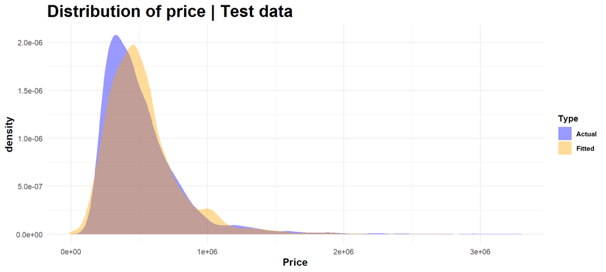

```r
my_col = c('blue','orange')
data.frame('Actual' = test_data2$price,
           'Fitted' = price_pred) %>%
  pivot_longer(Actual:Fitted, names_to = 'Type', values_to = 'Price') %>%
  ggplot(aes(Price, fill = Type)) + geom_density(alpha = 0.4, colour = NA) +
  scale_fill_manual(values = my_col) + theme_minimal() +
  labs(title = 'Distribution of price | Test data')+
  theme(plot.title = element_text(face = 'bold', size = 20),
      axis.title = element_text(face = 'bold', size = 12),
      legend.title = element_text(face = 'bold', size = 10),
      legend.text = element_text(face = 'bold', size = 8))
```

**Comment:** The distributions of predicted and actual price are close to each other.